# Label-free Quantification Proteomics

## Summarising to protein-level abundances

We can now summarise to protein-level abundance. Below, we use ‘robust’ summarisation (Sticker et al. 2020) with `MSnbase::combineFeatures()`. This returns a warning about missing values that we can ignore here since the robust method is inherently designed to handle missing values. See `MsCoreUtils::robustSummary()` and [this publication](https://pubmed.ncbi.nlm.nih.gov/32321741/) for further details about the robust method.

```r
prot_robust <- pep_restricted %>%
  MSnbase::combineFeatures(
    # group the peptides by their master protein id
    groupBy = fData(pep_restricted)$Master.Protein.Accessions,
    method = 'robust',
    maxit = 1000  # Ensures convergence for MASS::rlm
  )
```

```
#> Your data contains missing values. Please read the relevant section in
#> the combineFeatures manual page for details on the effects of missing
#> values on data aggregation.
```

We can then re-inspect the missing values at the protein level. So, we have quantification for 505 proteins, of which 288 are fully quantified across all 8 samples. The most common missing values pattern remains missing in just RNase negative replicate 4.

```r
p <- MSnbase::plotNA(prot_robust, pNA = 0) +
  camprotR::theme_camprot(border = FALSE, base_family = 'sans', base_size = 15)
```

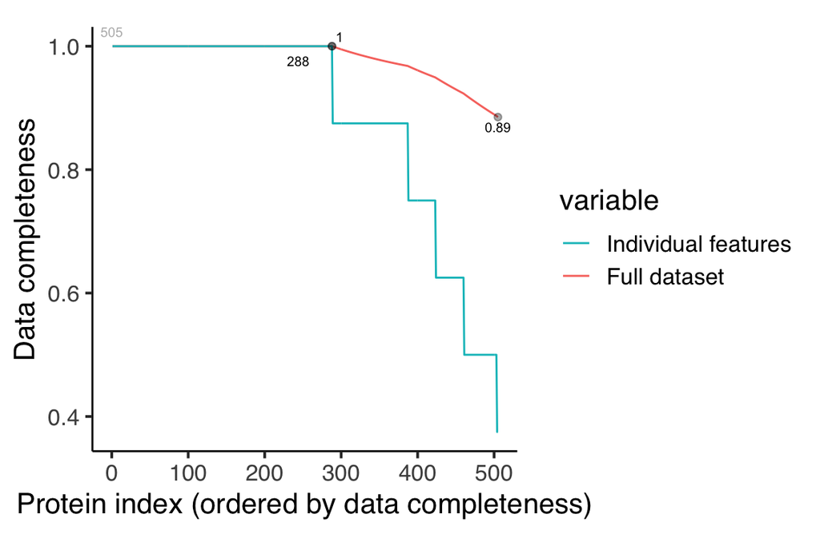

```r
print(p)
```

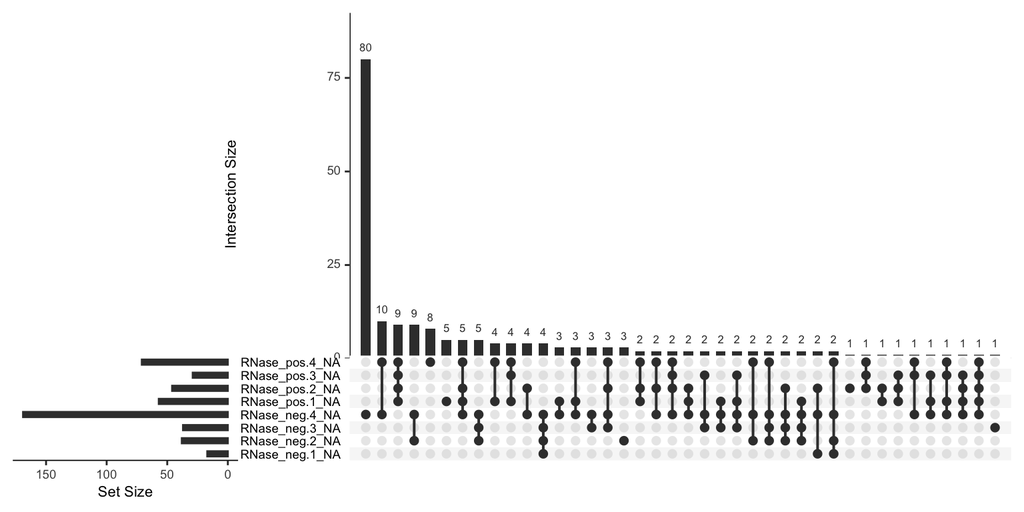

```r
naniar::gg_miss_upset(data.frame(exprs(prot_robust)),
                      sets = paste0(colnames(prot_robust), '_NA'),
                      keep.order = TRUE,
                      nsets = 10)
```

We have now processed our peptide-level LFQ abundances and obtained protein-level abundances, from which we can perform our downstream analyses.

Below, we save the protein level objects to disk, so we can read them back into memory in downstream analyses. We use `saveRDS` to save them in compressed R binary format.

```r
saveRDS(prot_robust, 'results/lfq_prot_robust.rds')
```

### Optional extra sections on normalisation and summarisation

For a comparison between `robust` and `maxLFQ` for summarisation to protein-level abundances, see the notebook [Alternatives for summarising to protein-level abundance - MaxLFQ](https://mrctoxbioinformatics.github.io/Proteomics_data_analysis/Markdowns/LFQ_maxlfq.html)

For a demonstration of an alternative normalisation approach where one has a strong prior belief, see [Normalisation to a prior expectation](https://mrctoxbioinformatics.github.io/Proteomics_data_analysis/Markdowns/LFQ_alternative_normalisation.html)

We will also save the `pep_restricted` object, since this is used in [Alternatives for summarising to protein-level abundance - MaxLFQ](https://mrctoxbioinformatics.github.io/Proteomics_data_analysis/Markdowns/LFQ_maxlfq.html)

```r
saveRDS(pep_restricted, 'results/lfq_pep_restricted.rds')
```

## References

Cox, Jürgen, Marco Y. Hein, Christian A. Luber, Igor Paron, Nagarjuna Nagaraj, and Matthias Mann. 2014. “Accurate Proteome-Wide Label-Free Quantification by Delayed Normalization and Maximal Peptide Ratio Extraction, Termed MaxLFQ*.” *Molecular & Cellular Proteomics* 13 (9): 2513–26. https://doi.org/10.1074/mcp.M113.031591.

Queiroz, Rayner M. L., Tom Smith, Eneko Villanueva, Maria Marti-Solano, Mie Monti, Mariavittoria Pizzinga, Dan-Mircea Mirea, et al. 2019. “Comprehensive Identification of RNA–Protein Interactions in Any Organism Using Orthogonal Organic Phase Separation (OOPS).” *Nature Biotechnology* 37 (2): 169. https://doi.org/10.1038/s41587-018-0001-2.

Sticker, Adriaan, Ludger Goeminne, Lennart Martens, and Lieven Clement. 2020. “Robust Summarization and Inference in Proteome-wide Label-free Quantification.” *Molecular & cellular proteomics: MCP* 19 (7): 1209–19. https://doi.org/10.1074/mcp.RA119.001624.

Välikangas, Tommi, Tomi Suomi, and Laura L Elo. 2018. “A Systematic Evaluation of Normalization Methods in Quantitative Label-Free Proteomics.” *Briefings in Bioinformatics* 19 (1): 1–11. https://doi.org/10.1093/bib/bbw095.